# Introduction to SC19003

19003

2020-01-02

## Overview

**SC19003** is a simple R package developed to calculate the main quantitative metric describing the queuing system in the queuing service system. These are the length of the queue (Ls), the average waiting time of the customer and the average stay time (Ws), and whether the system is busy. During simulation, there are three key variables: time variable, counting variable, and system state variable. The time variable mainly records the arrival or departure of customers. The counting variable records the number of customers in the service system. The system state variable mainly records the number of customers in the system and which service desk they are at.

In queued service systems, it is usually assumed that the successive arrival intervals of customers to the system are independent and subject to an exponential distribution with a parameter of $\lambda$. The service time of the service desk is also iid., and obeys the exponential distribution of parameter $\mu$. Queues are allowed forever. Two functions are considered, namely, *quene1* (Assuming that there is only one service counters) and *queue2* (Assuming that the number of service counters is greater than 1).

The source R code for *queue1* is as follows:

```r
queue1<-function(lambda, mu, T){
  k<-0; wt<-0; wn<-0; ws<-0;
  tp<-0; nA<-0; n<-0; t<-0
  r<-runif(1); tA<--1/lambda*log(r); tD<-Inf
  repeat{
    k<-k+1; wt[k]<-t; wn[k]<-n
    if (tA < T){
      ws[k]<-min(tA, tD)-t
      if (tA < tD){
        t<-tA; n<-n+1; nA<-nA+1
        r<-runif(1); tA<-t-1/lambda*log(r)
        if (n==1){
          r<-runif(1); tD<-t-1/mu*log(r)
        }
      }else{
        t<-tD; n<-n-1
        if (n==0){
          tD<-Inf
        }else{
          r<-runif(1); tD<-t-1/mu*log(r)
        } }
    }else{
      ws[k]<-if(tD==Inf) 0 else tD-t
      if (n>0){
        t<-tD; n<-n-1
        if (n>0){
          r<-runif(1); tD<-t-1/mu*log(r)
        }
      }else
        tp<-1
    }

    if (tp==1) break
  }
  data.frame(Ls=sum(ws*wn)/t, Ws=sum(ws*wn)/nA,
             Pwait=sum(ws[wn>=1])/t)
}
```

Suppose a maintenance center only arranges for one employee to provide services on weekends. It is assumed that the arrival process of customers for maintenance is Possion flow, with an average of 4 people per hour. The maintenance time follows an exponential distribution, taking an average of 6 minutes. This function is used to calculate the length of the queue ($Ls$), the average length of stay ($Ws$), and the probability of customer waiting (the probability of system busy) ($Pwait$).

```r
library(SC19003)
result1 <- queue1(4,10,10000) # we assume that queues are allowed forever so the parameter T is 10000 (a large number).
result1
```

```
##          Ls       Ws     Pwait
## 1 0.6690723 0.167033 0.3996172
```

The source R code for *queue2* is as follows:

```r
queue2<-function(lambda, mu, T, S){
  k<-0; wt<-0; wn<-0; ws<-0
  tp<-0; nA<-0; t<-0
  r<-runif(1); tA<--1/lambda*log(r)
  tD<-rep(Inf, S); SS<-rep(0, S+1)
  repeat{
    t1<-if(SS[1]==0) Inf else min(tD)
    i1<-if(SS[1]==0) 1 else which.min(tD)
    k<-k+1; wt[k]<-t; wn[k]<-SS[1]
    if (tA < T){
      ws[k]<-min(tA, t1)-t
      if (tA < t1){
        t<-tA; nA<-nA+1
        r<-runif(1); tA<-t-1/lambda*log(r)
        n<-SS[1]; SS[1]<-n+1
        for (i in 1:S){
          if (SS[1+i]==0){
            SS[1+i]<-1
            r<-runif(1); tD[i]<-t-1/mu*log(r)
            break
          }
        }

      }else{
        t<-t1; n<-SS[1]; SS[1]<-n-1
        if (n==1){
          SS[2:(S+1)]<-0; tD[1:S]<-Inf
        }else if (n<=S){
          SS[1+i1]<-0; tD[i1]<-Inf
        }else{
          r<-runif(1); tD[i1]<-t-1/mu*log(r)
        } }
    }else{
      ws[k]<- if( t1==Inf) 0 else t1-t
      n<-SS[1]
      if (n>0){
        t<-t1; SS[1]<-n-1;
        if (n==1){
          SS[2:(S+1)]<-0; tD[1:S]<-Inf
        }else if (n<=S){
          SS[1+i1]<-0; tD[i1]<-Inf
        }else{
          r<-runif(1); tD[i1]<-t-1/mu*log(r)
        }
      }else
        tp<-1
    }
    if (tp==1) break
  }
  data.frame(Ls=sum(ws*wn)/t, Ws=sum(ws*wn)/nA,
             Pwait=sum(ws[wn>=S])/t)
}
```

Suppose there are three typists in the printing room, the average printing time of each document is 10 minutes, and the reaching rate of documents is 15 pieces per hour. Use the function to calculate the length of the file queue ($Ls$), the average staying time ($Ws$) and the probability of waiting ($Pwait$).

```r
library(SC19003)
result2 <- queue2(15,6,1000,3) # we assume that queues are allowed forever so the parameter T is 1000 (a large number).
result2
```

```
##         Ls        Ws     Pwait
## 1 5.987955 0.3989681 0.7031397
```

# Homework 1

## Question

Use knitr to produce at least 3 examples(texts,figures,tables).

## text

This is the first assignment for this class and I hope the study of this course can go well in the future.

## figures & tables

```r
age <-c(21,30,35,44,45,33,25,27,29,48)
height <-c(160,162,165,158,155,164,162,150,167,161)
group <-gl(2,10,20,labels = c("age","height"))
weight <-c(age,height)
lm.D9 <-lm(weight~group)
summary(lm.D9)$coef
```

```
##             Estimate Std. Error  t value     Pr(>|t|)
## (Intercept)     33.7   2.338684 14.40981 2.518398e-11
## groupheight    126.7   3.307399 38.30805 1.050118e-18
```

```r
knitr::kable(head(USJudgeRatings))
```

|  | CONT | INTG | DMNR | DILG | CFMG | DECI | PREP | FAMI | ORAL | WRIT | PHYS | RTEN |
| --- | --- | --- | --- | --- | --- | --- | --- | --- | --- | --- | --- | --- |
| AARONSON,L.H. | 5.7 | 7.9 | 7.7 | 7.3 | 7.1 | 7.4 | 7.1 | 7.1 | 7.1 | 7.0 | 8.3 | 7.8 |
| ALEXANDER,J.M. | 6.8 | 8.9 | 8.8 | 8.5 | 7.8 | 8.1 | 8.0 | 8.0 | 7.8 | 7.9 | 8.5 | 8.7 |
| ARMENTANO,A.J. | 7.2 | 8.1 | 7.8 | 7.8 | 7.5 | 7.6 | 7.5 | 7.5 | 7.3 | 7.4 | 7.9 | 7.8 |
| BERDON,R.I. | 6.8 | 8.8 | 8.5 | 8.8 | 8.3 | 8.5 | 8.7 | 8.7 | 8.4 | 8.5 | 8.8 | 8.7 |
| BRACKEN,J.J. | 7.3 | 6.4 | 4.3 | 6.5 | 6.0 | 6.2 | 5.7 | 5.7 | 5.1 | 5.3 | 5.5 | 4.8 |
| BURNS,E.B. | 6.2 | 8.8 | 8.7 | 8.5 | 7.9 | 8.0 | 8.1 | 8.0 | 8.0 | 8.0 | 8.6 | 8.6 |

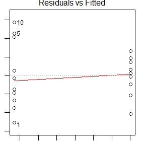

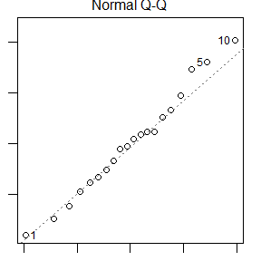

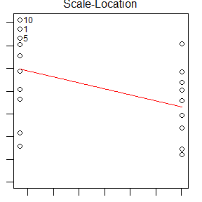

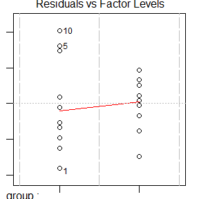

```r
par(mar=c(1,1,1,1))
plot(lm.D9)
```

# Homework 2

## Question 3.4

The Rayleigh density [156, Ch. 18] is

$f(x)=\frac{x}{\sigma^{2}} e^{-x^{2} /\left(2 \sigma^{2}\right)}, \quad x \geq 0, \sigma>0$

Develop an algorithm to generate random samples from a Rayleigh(σ) distribution. Generate Rayleigh(σ) samples for several choices of σ > 0 and check that the mode of the generated samples is close to the theoretical mode σ (check the histogram).

## Answer

### sigma = 1

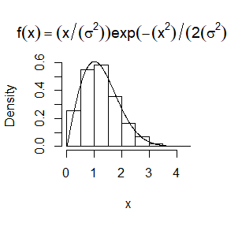

```r
n<-1000
u<-runif(n)
sigma<-1
x<-(-2*(sigma^2)*log(u))^(1/2)
hist(x,probability = T,main = expression(f(x)==(x/(sigma^2))*exp(-(x^2)/(2*(sigma^2)))))
y <- seq(0,4,0.01)
lines(y,y/(sigma^2)*exp(-(y^2)/(2*(sigma^2))))
```

### sigma = 2

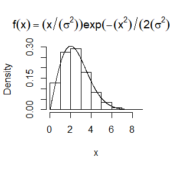

```r
sigma<-2
x<-(-2*(sigma^2)*log(u))^(1/2)
hist(x,probability = T,main = expression(f(x)==(x/(sigma^2))*exp(-(x^2)/(2*(sigma^2)))))
y <- seq(0,8,0.01)
lines(y,y/(sigma^2)*exp(-(y^2)/(2*(sigma^2))))
```

### sigma = 4

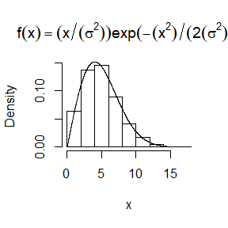

```r
sigma<-4
x<-(-2*(sigma^2)*log(u))^(1/2)
hist(x,probability = T,main = expression(f(x)==(x/(sigma^2))*exp(-(x^2)/(2*(sigma^2)))))
y <- seq(0,15,0.01)
lines(y,y/(sigma^2)*exp(-(y^2)/(2*(sigma^2))))
```

## Question 3.11

Generate a random sample of size 1000 from a normal location mixture. The components of the mixture have N(0, 1) and N(3, 1) distributions with mixing probabilities p1 and p2 = 1 − p1. Graph the histogram of the sample with density superimposed, for p1 = 0.75. Repeat with different values for p1and observe whether the empirical distribution of the mixture appears to be bimodal. Make a conjecture about the values of p1 that produce bimodal mixtures.

## Answer

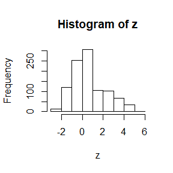

```r
library(MASS)
n<-1000
x1<-rnorm(n,0,1)
x2<-rnorm(n,3,1)
p <- 0.75
r<-sample(c(0,1),n,replace = TRUE,prob = c(p,1-p))
z<-(1-r)*x1+r*x2
hist(z)
```

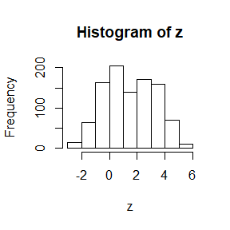

```r
p <- 0.5
r<-sample(c(0,1),n,replace = TRUE,prob = c(p,1-p))
z<-(1-r)*x1+r*x2
hist(z)
```

## Question 3.18

Write a function to generate a random sample from a Wd(Σ, n) (Wishart) distribution for n > d + 1 ≥ 1, based on Bartlett’s decomposition.

## Answer

```r
n <- 10
sigma_1 <-4 * diag(4)
Wd<-function(sigma_1,n){
  p<-nrow(sigma_1)
  l<-chol(sigma_1)
  A<-matrix(nrow = p,ncol = p)
  A[upper.tri(A)]<-0
  c<-numeric(p)
  for (i in 1:p){
    c[i]<-rchisq(1,n-i+1)
  }
  diag(A)<-c
  A[lower.tri(A)]<-rnorm((p^2-p)/2)
  s<-l%*%A%*%t(A)%*%t(l)
  return(s)
}
Wd(sigma_1,n)
```

```
##           [,1]      [,2]       [,3]       [,4]
## [1,] 209.78559  23.43977 -29.522746 -11.993186
## [2,]  23.43977 333.40762 -43.041769  31.231173
## [3,] -29.52275 -43.04177  76.556620   7.421434
## [4,] -11.99319  31.23117   7.421434  62.765253
```

# Homework 3

## Question 5.1

Compute a Monte Carlo estimate of

$\int_{0}^{\pi / 3} \sin t d t$

and compare your estimate with the exact value of the integral.

## Answer

```r
set.seed(123)
m<-10000
x<-runif(m,min = 0,max = pi/3)
theta.hat<-mean(sin(x))*(pi/3)
print(c(theta.hat,cos(0)-cos(pi/3)))
```

```
## [1] 0.49808 0.50000
```

## Question 5.10

Use Monte Carlo integration with antithetic variables to estimate

$\int_{0}^{1} \frac{e^{-x}}{1+x^{2}} d x$

and find the approximate reduction in variance as a percentage of the variance without variance reduction.

## Answer

```r
set.seed(12345)
n<-10000
u<-runif(n)
y1<-exp(-u)/(1+u^2)
y2<-exp(u-1)/(1+(1-u)^2)
y0<-c(y1,y2)
Use<-mean(y0)
Use
```

```
## [1] 0.5243804
```

```r
var0<-(1/4)*var(y1)+(1/4)*var(y2)+(1/2)*cov(y1,y2)
var0
```

```
## [1] 0.00108792
```

```r
set.seed(12345)
n<-10000
u<-runif(n)
y<-exp(-u)/(1+u^2)
Ise<-mean(y)
Ise
```

```
## [1] 0.5237823
```

```r
var(y)
```

```
## [1] 0.05942649
```

```r
(var(y)-var0)/(var(y))
```

```
## [1] 0.981693
```

## Question 5.15

Obtain the stratified importance sampling estimate in Example 5.13 and compare it with the result of Example 5.10.

```r
set.seed(0)
m<-numeric(6)
a<-c(0,0.2,0.4,0.6,0.8,1)
for (i in 1:6){
  m[i]<--log(1-a[i]*(1-exp(-1)))
}
print(m)
```

```
## [1] 0.0000000 0.1351603 0.2914869 0.4768628 0.7046055 1.0000000
```

```r
## stratified importance sampling estimate
M <- 10000
k <- 5
r <- M / k
N <- 50
T2 <- numeric(k)
estimates <- matrix(0, N, 2)
g<-function(x) {
  exp(-x)/(1+x^2)*(x>0)*(x<1)
}

for (i in 1:N) {
  u<-runif(m)
  x<--log(1-u*(1-exp(-1)))    # inverse transformated method
  g1<-g(x)/(exp(-x)/(1-exp(-1)))
  estimates[i,1]<-mean(g1)
  for (j in 1:k) {
    v<-runif(m/5)
    y<--log(exp(-m[j])-v/5*(1-exp(-1)))
    g2<-g(y)/(5*exp(-y)/(1-exp(-1)))
    T2[j]<-mean(g2)
  }
estimates[i,2]<-sum(T2)
}
print(estimates)
```

```
##            [,1]      [,2]
##  [1,] 0.5141923 0.5254007
##  [2,] 0.4985529 0.5270709
##  [3,] 0.4866306 0.5252333
##  [4,] 0.4684848 0.5242017
##  [5,] 0.5565671 0.5210239
##  [6,] 0.4846112 0.5241266
##  [7,] 0.4982429 0.5261936
##  [8,] 0.5381037 0.5347022
##  [9,] 0.5736298 0.5261270
## [10,] 0.4186641 0.5246105
## [11,] 0.5536839 0.5247749
## [12,] 0.5664161 0.5186065
## [13,] 0.5434959 0.5278178
## [14,] 0.5052709 0.5263202
```

[output cut: 36 more lines]

```r
apply(estimates, 2, mean)
```

```
## [1] 0.5229190 0.5254649
```

```r
apply(estimates, 2, var)
```

```
## [1] 1.565651e-03 1.280849e-05
```

```r
print((var(estimates[,1])-var(estimates[,2]))/var(estimates[,1]))
```

```
## [1] 0.9918191
```

# Homework 4

## Question 6.5

Suppose a 95% symmetric t-interval is applied to estimate a mean, but the sample data are non-normal. Then the probability that the confidence interval covers the mean is not necessarily equal to 0.95. Use a Monte Carlo experiment to estimate the coverage probability of the t-interval for random samples of $\chi^{2}(2)$ data with sample size n = 20. Compare your t-interval results with the simulation results in Example 6.4. (The t-interval should be more robust to departures from normality than the interval for variance.)

## Answer

### The coverage probability of the t-interval

```r
n <- 20
set.seed(012345678)
alpha <- 0.05
CL<-replicate(1000,expr={
  x <- rchisq(n, df = 2)
  UCL<-mean(x) +qt(1-alpha/2, df = n-1)*sd(x)/sqrt(n)
  LCL<-mean(x) - qt(1-alpha/2, df = n-1)*sd(x)/sqrt(n)
  c(LCL,UCL)
})
cum<-0
a<-2
for (i in 1:1000){
  if(CL[1,i]<a && a < CL[2,i] )
  cum <- cum + 1
  }
cp<- cum/1000
print(cp)
```

```
## [1] 0.912
```

### Compare the t-interval results with the simulation results in Example 6.4

```r
set.seed(1)
n <- 20
alpha <- .05
UCL <- replicate(1000, expr = {
x <- rchisq(n, df = 2)
(n-1) * var(x) / qchisq(alpha, df = n-1)
} )
sum(UCL > 4)
```

```
## [1] 797
```

```r
mean(UCL >4)
```

```
## [1] 0.797
```

```r
## The t-interval should be more robust to departures from normality than the interval for variance.In this experiment, only 797 or 79.7% of the intervals contained the population variance.
```

## Question 6.6

Estimate the 0.025, 0.05, 0.95, and 0.975 quantiles of the skewness $\sqrt{b_{1}}$ under normality by a Monte Carlo experiment. Compute the standard error of the estimates from (2.14) using the normal approximation for the density (with exact variance formula). Compare the estimated quantiles with the quantiles of the large sample approximation $\sqrt{b_{1}} \approx N(0,6 / n)$.

## Answer

```r
set.seed(123)
N <- 50
sk <- function(x) {
                  xbar <- mean(x)
                  m3 <- mean((x - xbar)^3)
                  m2 <- mean((x - xbar)^2)
                  return( m3 / m2^1.5 )
}
estimates <- matrix(0, N, 1)
for(i in 1:N){
  x <- rnorm(1000)
  estimates[i]<-sk(x)
}
```

### Estimate the 0.025, 0.05, 0.95, and 0.975 quantiles

```r
q <- numeric(4)
a <-c(0.025,0.05,0.95,0.975)
for(i in 1:4){
           q[i]<- quantile(estimates,a[i])
}
print(q)
```

```
## [1] -0.1295104 -0.1133682  0.1453194  0.1473866
```

### Compute the standard error of the estimates

```r
var <- matrix(0, 4, 1)
g <- function(x){a[i]*(1-a[i])/(N*dnorm(x,0,1)^2)
}
for(i in 1:4){
            var[i] <- g(q[i])
     }
print(sqrt(var))
```

```
##            [,1]
## [1,] 0.05581095
## [2,] 0.07775755
## [3,] 0.07807957
## [4,] 0.05594925
```

### The quantiles of the large sample approximation $\sqrt{b_{1}} \approx N(0,6 / n)$

```r
set.seed(123)
n <- 1000
x <- rnorm(n,mean = 0,sd=(6/n)^(1/2))
q2 <- numeric(4)
a <-c(0.025,0.05,0.95,0.975)
for(i in 1:4){
           q2[i]<- quantile(x,a[i])
}
print(q2)
```

```
## [1] -0.1503922 -0.1256848  0.1298328  0.1578540
```

### Compare the quantiles

```r
cbind(q,q2)
```

```
##               q         q2
## [1,] -0.1295104 -0.1503922
## [2,] -0.1133682 -0.1256848
## [3,]  0.1453194  0.1298328
## [4,]  0.1473866  0.1578540
```

# Homework 5

## Question 1

Estimate the power of the skewness test of normality against symmetric Beta($\alpha$,$\alpha$) distributions and comment on the results. Are the results different or heavy-tailed symmetric alternatives such as t($\nu$)?

## Answer 1

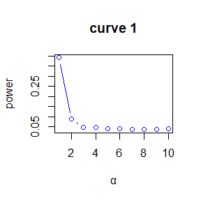

```r
library(energy)
set.seed(1)
alpha <- .05
n <- 30
m <- 2000
exam1 <- exam2 <- numeric(m)
para1 <- para2 <- 1:10
pwr1 <- pwr2 <- numeric(10)

## Estimate the power of the skewness test of normality against symmetric Beta(α, α) distributions
for (i in 1:10) {
  for (j in 1:m) {
    x <- rbeta(n,para1[i],para1[i])
    exam1[j] <- as.integer(
    shapiro.test(x)$p.value <= alpha)
  }
  pwr1[i] <- mean(exam1)
}
plot(para1,pwr1,main = "curve 1",xlab = "α",ylab = "power",type = "b",col = "blue")
```

```r
print(pwr1)
```

```
##  [1] 0.3910 0.0880 0.0465 0.0480 0.0395 0.0410 0.0345 0.0365 0.0355 0.0395
```

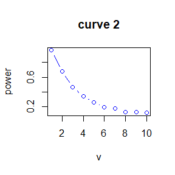

```r
#Estimate the power of the skewness test of normality against symmetric t(ν) distributions
for (j in 1:10) {
  for (i in 1:m) {
    y <- rt(n,para2[j])
    exam2[i] <- as.integer(
    shapiro.test(y)$p.value <= alpha)
  }
  pwr2[j] <- mean(exam2)
}
plot(para2,pwr2,main = "curve 2",xlab = "ν",ylab = "power",type = "b",col = "blue")
```

```r
print(pwr2)
```

```
##  [1] 0.9635 0.6780 0.4655 0.3455 0.2630 0.1945 0.1755 0.1300 0.1330 0.1180
```

*Conclusion:* From the figure curve 1, we can find that the value of the power falls from o.38 to 0.03. And from the figure curve 2, we can find that it is similar to the curve 1, but in the curve 2, the range is even wider,which means t(ν) is more closer to normal distribution than Beta(α, α).

## Question 2

Use Monte Carlo simulation to investigate whether the empirical Type I error rate of the t-test is approximately equal to nominal significance level $\alpha$, when the sampled population is non-normal. The t-test is robust to mild departures from normality. Discuss the simulation results for the cases where the sampled population is (i) $\chi^2(1)$, (ii) Uniform(0,2), and (iii) Exponential(rate=1). In each case, test $H_0:\mu=\mu_0$ vs $H_1:\mu \neq \mu_0$, where $\mu_0$ is the mean of $\chi^2(1)$, Uniform(0,2), and Exponential(1), respectively.

## Answer 2

```r
set.seed(12345678)
n<-50
alpha <- .05
a<-1
mu0<-1
m <- 10000
#number of replicates
p <- numeric(m)
#storage for p-values
for (j in 1:m) {
  x <- rchisq(n, 1)
  ttest <- t.test(x, alternative = "two.sided", mu = mu0)
  p[j] <- ttest$p.value
  }
p.hat <- mean(p < alpha)
print(p.hat)
```

```
## [1] 0.0797
```

```r
for (j in 1:m) {
  x <- runif(n, 0, 2)
  ttest <- t.test(x, alternative = "two.sided", mu = mu0)
  p[j] <- ttest$p.value
  }
p.hat <- mean(p < alpha)
print(p.hat)
```

```
## [1] 0.0516
```

```r
for (j in 1:m) {
  x <- rexp(n, 1)
  ttest <- t.test(x, alternative = "two.sided", mu = mu0)
  p[j] <- ttest$p.value
  }
p.hat <- mean(p < alpha)
print(p.hat)
```

```
## [1] 0.0679
```

## discussion 3

If we obtain the powers for two methods under a particular simulation setting with 10000 experiments: say, 0.651 for one method and 0.676 for another method. Can we say the powers are different at 0.05 level?

1.What is the corresponding hypothesis test problem?

2.What test should we use? Z-test, two-sample test, paired-t test or McNemar test?

3.What information is needed to test your hypothesis?

## Answer 3

##### 1.

$$H_{0}: \text { power } 1=\text { power } 2 \quad \text { versus } \quad H_{1}: \text { power } 1 \neq \text { power } 2$$

##### 2. I think we should use McNemar test. First, McNemar test is suitable for Chi-square test of non-independent samples. In this test, the z-assignment test is based on a large sample size. And the test is for the difference in the proportion of dependent samples.

##### 3. The number of simultanously regection.

# Homework 6

## Question 7.6

Efron and Tibshirani discuss the scor (bootstrap) test score data on 88 students who took examinations in five subjects [84, Table 7.1], [188, Table 1.2.1]. The first two tests (mechanics, vectors) were closed book and the last three tests (algebra, analysis, statistics) were open book. Each row of the data frame is a set of scores $\left(x_{i 1}, \dots, x_{i 5}\right)$ for the $i^{t h}$ student. Use a panel display to display the scatter plots for each pair of test scores. Compare the plot with the sample correlation matrix. Obtain bootstrap estimates of the standard errors for each of the following estimates:$\hat{\rho}_{12}=\hat{\rho}(\mathrm{mec}, \mathrm{vec}), \hat{\rho}_{34}=\hat{\rho}(\mathrm{alg,ana})$, $\hat{\rho}_{35}=\hat{\rho}(\text { alg, sta }), \hat{\rho}_{45}=\hat{\rho}(\text { ana }, \text { sta })$.

## Answer 7.6

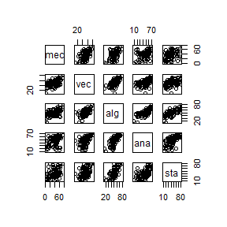

```r
library(bootstrap)
## Use a panel display to display the scatter plots for each pair of test scores.
library(ggplot2)
pairs(~mec+vec+alg+ana+sta,scor)
```

```r
##  Compare the plot with the sample correlation matrix.
cor(scor)
```

```
##           mec       vec       alg       ana       sta
## mec 1.0000000 0.5534052 0.5467511 0.4093920 0.3890993
## vec 0.5534052 1.0000000 0.6096447 0.4850813 0.4364487
## alg 0.5467511 0.6096447 1.0000000 0.7108059 0.6647357
## ana 0.4093920 0.4850813 0.7108059 1.0000000 0.6071743
## sta 0.3890993 0.4364487 0.6647357 0.6071743 1.0000000
```

```r
##  Obtain bootstrap estimates of the standard errors for each of the following estimates.
#set up the bootstrap
B <- 200
n <- nrow(scor)
rho12 <- numeric(B)
set.seed(1234)
```

##### bootstrap estimate of standard error of

$\hat{\rho}_{12}=\hat{\rho}(\mathrm{mec}, \mathrm{vec})$

```r
for (b in 1:B) {
i <- sample(1:n, size = n, replace = TRUE)
mec <- scor$mec[i]
vec <- scor$vec[i]
rho12[b] <- cor(mec, vec)
}

#output
print(se.rho12 <- sd(rho12))
```

```
## [1] 0.07476741
```

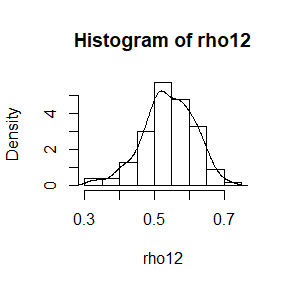

```r
hist(rho12, prob = TRUE)
lines(density(rho12))
```

##### bootstrap estimate of standard error of

$\hat{\rho}_{34}=\hat{\rho}(\mathrm{alg}, \mathrm{ana})$

```r
rho34 <- numeric(B)
for (b in 1:B) {
i <- sample(1:n, size = n, replace = TRUE)
alg <- scor$alg[i]
ana <- scor$ana[i]
rho34[b] <- cor(alg, ana)
}

#output
print(se.rho34 <- sd(rho34))
```

```
## [1] 0.05057228
```

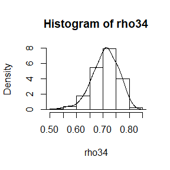

```r
hist(rho34, prob = TRUE)
lines(density(rho34))
```

##### bootstrap estimate of standard error of

$\hat{\rho}_{35}=\hat{\rho}(\mathrm{alg}, \mathrm{sta})$

```r
rho35 <- numeric(B)
for (b in 1:B) {
i <- sample(1:n, size = n, replace = TRUE)
alg <- scor$alg[i]
sta <- scor$sta[i]
rho35[b] <- cor(alg, sta)
}

#output
print(se.rho35 <- sd(rho35))
```

```
## [1] 0.06328222
```

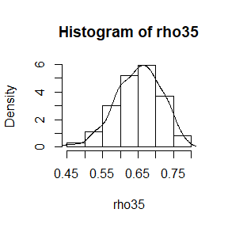

```r
hist(rho35, prob = TRUE)
lines(density(rho35))
```

##### bootstrap estimate of standard error of

$\hat{\rho}_{45}=\hat{\rho}(\mathrm{ana}, \mathrm{sta})$

```r
rho45 <- numeric(B)
for (b in 1:B) {
i <- sample(1:n, size = n, replace = TRUE)
ana <- scor$ana[i]
sta <- scor$sta[i]
rho45[b] <- cor(ana, sta)
}

#output
print(se.rho45 <- sd(rho45))
```

```
## [1] 0.06668089
```

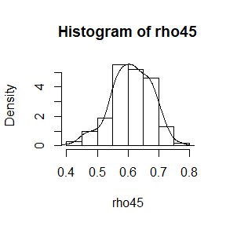

```r
hist(rho45, prob = TRUE)
lines(density(rho45))
```

```r
## Conclusion
library(knitr)
library(kableExtra)
knitr::kable(cbind(se.rho12,se.rho34,se.rho35,se.rho45),formate = "html",col.names = c("sd of rho12","sd of rho34","sd of rho35","sd of rho45")) %>% kable_styling(position = "center")
```

| sd of rho12 | sd of rho34 | sd of rho35 | sd of rho45 |
| --- | --- | --- | --- |
| 0.0747674 | 0.0505723 | 0.0632822 | 0.0666809 |

## 7.B

Repeat Project 7.A for the sample skewness statistic. Compare the coverage rates for normal populations (skewness 0) and $\chi^{2}(5)$ distributions (positive skewness).

```r
## basic settings
library(boot)
n<-1e2
set.seed(012345678)
mu<-0;b<-1;m<-80
sk<- function(x,i) {
  xbar <- mean(x[i])
  m3 <- mean((x[i] - xbar)^3)
  m2 <- mean((x [i]- xbar)^2)
  return( m3 / m2^1.5 )
}
## compute the coverage rates for normal populations
norm_cil<-norm_cir<-basic_cil<-basic_cir<-perc_cil<-perc_cir<-numeric(n)
for(i in 1:m){
 U<-rnorm(m,0,1)
  de <- boot(data=U,statistic=sk, R = 2000)
  ci <- boot.ci(de ,type=c("norm","basic","perc"))
  norm_cil[i]<-ci$normal[2]
  norm_cir[i]<-ci$normal[3]
  basic_cil[i]<-ci$basic[4]
  basic_cir[i]<-ci$basic[5]
  perc_cil[i]<-ci$percent[4]
  perc_cir[i]<-ci$percent[5]
}
cat('norm =',round(mean(norm_cil<=mu & norm_cir>=mu),4),
    'basic =',mean(basic_cil<=mu & basic_cir>=mu), 'perc =',mean(perc_cil<=mu & perc_cir>=mu))
```

```
## norm = 0.93 basic = 0.94 perc = 0.95
```

```r
#  compute the coverage rates for chi-square(5) distributions
set.seed(012345678)
sk<- function(x,i) {
  xbar <- mean(x[i])
  m3 <- mean((x[i] - xbar)^3)
  m2 <- mean((x [i]- xbar)^2)
  return( m3 / m2^1.5 )
}
n<-500
m<-200
norm_cil<-norm_cir<-basic_cil<-basic_cir<-perc_cil<-perc_cir<-numeric(n)

for (i in 1:n) {
  x<-rchisq(m,5)
  boot.obj<-boot(x,statistic=sk,R=2000)
  ci<-boot.ci(boot.obj,type=c('norm','basic','perc'))
  norm_cil[i]<-ci$normal[2]
  norm_cir[i]<-ci$normal[3]
  basic_cil[i]<-ci$basic[4]
  basic_cir[i]<-ci$basic[5]
  perc_cil[i]<-ci$percent[4]
  perc_cir[i]<-ci$percent[5]
}
# compute coverage rates
a<-sqrt(8/5)
print(c(mean((norm_cil<a)*(norm_cir>a)),mean((basic_cil<a)*(basic_cir>a)),mean((perc_cil<a)*(perc_cir>a))))
```

```
## [1] 0.814 0.808 0.802
```

# Homework 7

## Question 7.8

Refer to Exercise 7.7. Obtain the jackknife estimates of bias and standard error of $\hat{\theta}$.

## Answer

```r
set.seed(0)
library(bootstrap)
library(knitr)
lamda_hat <- eigen(cov(scor))$values
theta_hat <- lamda_hat[1]/sum(lamda_hat)
print(theta_hat)
```

```
## [1] 0.619115
```

```r
n<-nrow(scor)
theta.j<-numeric(n)
ev<-matrix(nrow = 88,ncol = 5)

for (i in 1:n){
  ev[i,]<- eigen(cov(scor[-i,]))$values
  theta.j[i]<-ev[i,1]/sum(ev[i,])}

bias.j<-(n-1)*(mean(theta.j)-theta_hat)
se.j<-sqrt((n-1)*mean((theta.j-mean(theta.j))^2))
print(bias.j)
```

```
## [1] 0.001069139
```

```r
print(se.j)
```

```
## [1] 0.04955231
```

```r
library(kableExtra)
knitr::kable(cbind(theta_hat,bias.j,se.j),formate = "html",col.names = c("theta_hat","bias.j","se.j")) %>% kable_styling(position = "center")
```

| theta_hat | bias.j | se.j |
| --- | --- | --- |
| 0.619115 | 0.0010691 | 0.0495523 |

## Question 7.10

In Example 7.18, leave-one-out (n-fold) cross validation was used to select the best fitting model. Repeat the analysis replacing the Log-Log model with a cubic polynomial model. Which of the four models is selected by the cross validation procedure? Which model is selected according to maximum adjusted $R^{2}$?

## Answer

```r
set.seed(123)
library(DAAG); attach(ironslag)
```

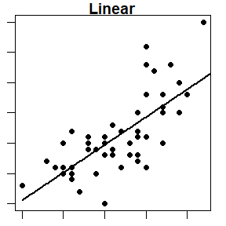

```r
a <- seq(10, 40, .1) #sequence for plotting fits

par(mar=c(1,1,1,1))
L1 <- lm(magnetic ~ chemical)
plot(chemical, magnetic, main="Linear", pch=16)
yhat1 <- L1$coef[1] + L1$coef[2] * a
lines(a, yhat1, lwd=2)
```

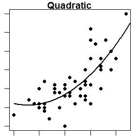

```r
L2 <- lm(magnetic ~ chemical + I(chemical^2))
plot(chemical, magnetic, main="Quadratic", pch=16)
yhat2 <- L2$coef[1] + L2$coef[2] * a + L2$coef[3] * a^2
lines(a, yhat2, lwd=2)
```

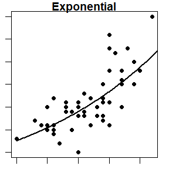

```r
L3 <- lm(log(magnetic) ~ chemical)
plot(chemical, magnetic, main="Exponential", pch=16)
logyhat3 <- L3$coef[1] + L3$coef[2] * a
yhat3 <- exp(logyhat3)
lines(a, yhat3, lwd=2)
```

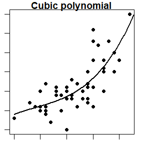

```r
L4 <- lm(magnetic ~ chemical + I(chemical^2) + I(chemical^3))
plot(chemical, magnetic, main="Cubic polynomial", pch=16)
yhat4 <- L4$coef[1] + L4$coef[2] * a + L4$coef[3] * a^2 + L4$coef[4] * a^3
lines(a, yhat4, lwd=2)
```

```r
## Cross validation
n <- length(magnetic) #in DAAG ironslag
e1 <- e2 <- e3 <- e4 <- numeric(n)
# for n-fold cross validation
# fit models on leave-one-out samples
for (k in 1:n) {
  y <- magnetic[-k]
  x <- chemical[-k]
J1 <- lm(y ~ x)
yhat1 <- J1$coef[1] + J1$coef[2] * chemical[k]
e1[k] <- magnetic[k] - yhat1

J2 <- lm(y ~ x + I(x^2))
yhat2 <- J2$coef[1] + J2$coef[2] * chemical[k] +
J2$coef[3] * chemical[k]^2
e2[k] <- magnetic[k] - yhat2

J3 <- lm(log(y) ~ x)
logyhat3 <- J3$coef[1] + J3$coef[2] * chemical[k]
yhat3 <- exp(logyhat3)
e3[k] <- magnetic[k] - yhat3

J4 <- lm(y ~ x + I(x^2) + I(x^3))
yhat4 <- J4$coef[1] + J4$coef[2] * chemical[k] + J4$coef[3] * chemical[k]^2 + J4$coef[4] * chemical[k]^3
e4[k] <- magnetic[k] - yhat4
}
c(mean(e1^2), mean(e2^2), mean(e3^2), mean(e4^2))
```

```
## [1] 19.55644 17.85248 18.44188 18.17756
```

```r
library(kableExtra)
knitr::kable(cbind(mean(e1^2), mean(e2^2), mean(e3^2), mean(e4^2)),formate = "html",col.names = c("mean(e1^2)", "mean(e2^2)", "mean(e3^2)", "mean(e4^2)")) %>% kable_styling(position = "center")
```

| mean(e1^2) | mean(e2^2) | mean(e3^2) | mean(e4^2) |
| --- | --- | --- | --- |
| 19.55644 | 17.85248 | 18.44188 | 18.17756 |

```r
## the values of Adjusted R-squared
knitr::kable(cbind(summary(lm(L1))$adj.r.squared,summary(lm(L2))$adj.r.squared,summary(lm(L3))$adj.r.squared,summary(lm(L4))$adj.r.squared),formate = "html",col.names = c("L1 adj-R^2","L2 adj-R^2","L3 adj-R^2","L4 adj-R^2")) %>% kable_styling(position = "center")
```

| L1 adj-R^2 | L2 adj-R^2 | L3 adj-R^2 | L4 adj-R^2 |
| --- | --- | --- | --- |
| 0.5281545 | 0.5768151 | 0.5280556 | 0.5740396 |

**Conclusion:** From the analysis, we can find the Quatradic model should be selceted by the cross validation procedure. Because 17.85248 is the smallest among the four values. But if according to the maximum adjusted $R^{2}$,the Quatradic model should be selected.

# Homework 8

## Question

The Count 5 test for equal variances in Section 6.4 is based on the maximum number of extreme points. Example 6.15 shows that the Count 5 criterion is not applicable for unequal sample sizes. Implement a permutation test for equal variance based on the maximum number of extreme points that applies when sample sizes are not necessarily equal.

## Answer

```r
set.seed(123)
n1 <- 30;n2 <- 50
mu1 <- mu2 <- 0;sigma1 <- sigma2 <- 1;m <- 10000
x <- rnorm(n1, mu1, sigma1)
y <- rnorm(n2, mu2, sigma2)

m1 <-log(.025) / log(n1 / (n1 + n2))
m2 <-log(.025) / log(n2 / (n1 + n2))
count5test <- function(x, y) {
X <- x - mean(x)
Y <- y - mean(y)
outx <- sum(X > max(Y)) + sum(X < min(Y))
outy <- sum(Y > max(X)) + sum(Y < min(X))
return(as.integer((outx > 4) | (outy > 7)))
}

R <- 10000
z <- c(x,y)
K <- n1 + n2
reps <- numeric(R)
t0 <- count5test(x,y)
for (i in 1:R) {
  k <- sample(K, size = n1, replace = FALSE)
  x1 <- z[k];y1 <- z[-k]
  X <- x1 - mean(x1); Y <- y1 - mean(y1)
  reps[i] <- count5test(x1, y1)
}

alphahat <- mean(c(t0, reps) > t0)
print(alphahat)
```

```
## [1] 0.06209379
```

## Question

Power comparison (distance correlation test versus ball covariance test)

Model 1:
$$Y=X / 4+e$$
Model 2:
$$Y=X / 4 \times e$$
$X \sim N\left(0_{2}, l_{2}\right), e \sim N\left(0_{2}, l_{2}\right)$,$X$ and $e$ are independent.

## Answer

```r
# functions
dCov <- function(x, y) {
  x <- as.matrix(x); y <- as.matrix(y)
  n <- nrow(x); m <- nrow(y)
  if (n != m || n < 2) stop("Sample sizes must agree")
  if (! (all(is.finite(c(x, y)))))
  stop("Data contains missing or infinite values")
  Akl <- function(x) {
  d <- as.matrix(dist(x))
  m <- rowMeans(d); M <- mean(d)
  a <- sweep(d, 1, m); b <- sweep(a, 2, m)
  b + M
  }
A<- Akl(x); B <- Akl(y)
sqrt(mean(A * B))
}

ndCov2 <- function(z, ix, dims) {
p <- dims[1]
q <- dims[2]
d <- p + q
x <- z[ , 1:p] #leave x as is
y <- z[ix, -(1:p)] #permute rows of y
return(nrow(z) * dCov(x, y)^2)
}

library(Ball)
```

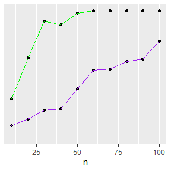

```r
library(mvtnorm)
library(boot)
n<-seq(from=10,to=100,by=10)
k<-100
alpha<-0.05
pow_dCor_Model1<-pow_ball_Model1<-pow_dCor_Model2<-pow_ball_Model2<-numeric(length(n))
for (j in 1:length(n)) {

  #storage of temp data
  p_ball1<-numeric(k)
  dcor1<-numeric(k)
  p_ball2<-numeric(k)
  dcor2<-numeric(k)
  dcor1<-dcor2<-p_ball1<-p_ball2<-numeric(k)
  for (i in 1:k) {
    set.seed(i)
    # the function "rmvnorm" is used to
    # generate the multidimensional normal data
    X<-rmvnorm(n[j],rep(0,2),diag(1,2))
    err<-rmvnorm(n[j],rep(0,2),diag(1,2))
    Y1<-(X/4)+err
    Y2<-(X/4)*err
    Z1<-cbind(X,Y1)
    Z2<-cbind(X,Y2)
    t1<-bcov.test(X,Y2,R=99)
    p_ball1[i]<-t1$p.value
    boot.obj1<-boot(data=Z1,statistic=ndCov2,R=99,sim="permutation",dims=c(2, 2))
    temp1<-c(boot.obj1$t0, boot.obj1$t)
    dcor1[i]<-mean(temp1>=temp1[1])

    t2<-bcov.test(X,Y2,R=99)
    p_ball2[i]<-t2$p.value
    boot.obj2<-boot(data=Z2,statistic=ndCov2,R=99,sim="permutation",dims=c(2, 2))
    temp2<-c(boot.obj2$t0, boot.obj2$t)
    dcor2[i]<-mean(temp2>=temp2[1])
    }
  pow_dCor_Model1[j]<-mean(dcor1<alpha)
  pow_ball_Model1[j]<-mean(p_ball1<alpha)
  pow_dCor_Model2[j]<-mean(dcor2<alpha)
  pow_ball_Model2[j]<-mean(p_ball2<alpha)
}
dat<-data.frame(pow_dCor_Model1,pow_ball_Model1,pow_dCor_Model2,pow_ball_Model2)
# the red one is distance correlation test and the blue one is ballcovariance test
library(ggplot2)
ggplot(dat,aes(n))+geom_point(y=pow_dCor_Model1,fill="white")+geom_line(y=pow_dCor_Model1,colour="purple")+geom_point(y=pow_ball_Model1,fill="white")+geom_line(y=pow_ball_Model1,colour="green")
```

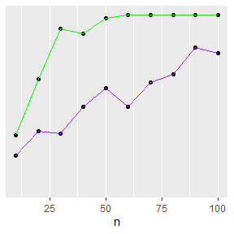

```r
ggplot(dat,aes(n))+geom_point(y=pow_dCor_Model2,fill="white")+geom_line(y=pow_dCor_Model2,colour="purple")+geom_point(y=pow_ball_Model2,fill="white")+geom_line(y=pow_ball_Model2,colour="green")
```

# Homework 9

## Question

Implement a random walk Metropolis sampler for generating the standard Laplace distribution (see Exercise 3.2). For the increment, simulate from a normal distribution. Compare the chains generated when different variances are used for the proposal distribution. Also, compute the acceptance rates of each chain.

## Answer

```r
library(VGAM)
library(knitr)
library(kableExtra)
set.seed(123)
    rw.Metropolis <- function(n, sigma, x0, N) {
        x <- numeric(N)
        x[1] <- x0
        u <- runif(N)
        k <- 0
        for (i in 2:N) {
            y <- rnorm(1, x[i-1], sigma)
                if (u[i] <= (dlaplace(y, 0, 1) / dlaplace(x[i-1], 0, 1)))
                    x[i] <- y
                else {
                    x[i] <- x[i-1]
                    k <- k + 1
                }
            }
        return(list(x=x, k=k))
    }

    N <- 2000
    sigma <- c(.05, .5, 2,  16)

    x0 <- 25
    rw1 <- rw.Metropolis(n, sigma[1], x0, N)
    rw2 <- rw.Metropolis(n, sigma[2], x0, N)
    rw3 <- rw.Metropolis(n, sigma[3], x0, N)
    rw4 <- rw.Metropolis(n, sigma[4], x0, N)

    #number of candidate points rejected
    no.reject <- data.frame(sigma=sigma,no.reject=c(rw1$k, rw2$k, rw3$k, rw4$k))
    knitr::kable(no.reject,format='html')%>% kable_styling(position = "center")
```

| sigma | no.reject |
| --- | --- |
| 0.05 | 32 |
| 0.50 | 337 |
| 2.00 | 944 |
| 16.00 | 1810 |

```r
    #compute the acceptance rates of each chain
    ar <- c(1-rw1$k/N, 1-rw2$k/N, 1-rw3$k/N, 1-rw4$k/N)
    print(ar)
```

```
## [1] 0.9840 0.8315 0.5280 0.0950
```

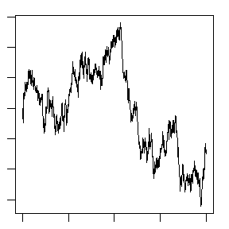

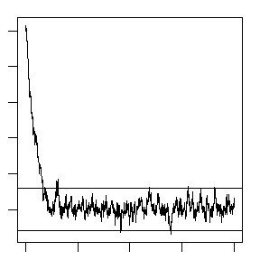

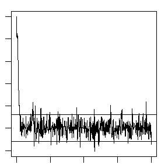

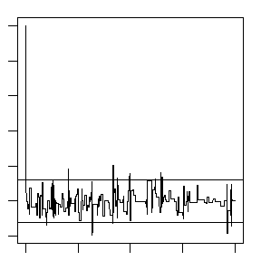

```r
    par(mar=c(1,1,1,1))  #display 4 graphs together
    refline <- qlaplace(c(.025, .975))
    rw <- cbind(rw1$x, rw2$x, rw3$x,  rw4$x)
    for (j in 1:4) {
        plot(rw[,j], type="l",
             xlab=bquote(sigma == .(round(sigma[j],3))),
             ylab="X", ylim=range(rw[,j]))
        abline(h=refline)
    }
```

```r
    par(mar=c(1,1,1,1)) #reset to default

    a <- c(.05, seq(.1, .9, .1), .95)
    Q <- qlaplace(a, 0, 1)
    rw <- cbind(rw1$x, rw2$x, rw3$x, rw4$x)
    mc <- rw[501:N, ]
    Qrw <- apply(mc, 2, function(x) quantile(x, a))
    qq <- data.frame(round(cbind(Q, Qrw), 3))
    names(qq) <- c('True','sigma=0.05','sigma=0.5','sigma=2','sigma=16')
    knitr::kable(qq,format='html')%>% kable_styling(position = "center")
```

|  | True | sigma=0.05 | sigma=0.5 | sigma=2 | sigma=16 |
| --- | --- | --- | --- | --- | --- |
| 5% | -2.303 | 23.781 | -1.314 | -2.186 | -1.970 |
| 10% | -1.609 | 23.848 | -0.937 | -1.599 | -1.639 |
| 20% | -0.916 | 24.039 | -0.559 | -0.836 | -0.747 |
| 30% | -0.511 | 24.305 | -0.295 | -0.384 | -0.255 |
| 40% | -0.223 | 24.487 | -0.098 | -0.114 | -0.141 |
| 50% | 0.000 | 24.808 | 0.070 | 0.089 | -0.015 |
| 60% | 0.223 | 25.326 | 0.252 | 0.279 | 0.070 |
| 70% | 0.511 | 25.538 | 0.555 | 0.502 | 0.331 |
| 80% | 0.916 | 25.674 | 0.856 | 0.938 | 0.782 |
| 90% | 1.609 | 25.918 | 1.351 | 1.582 | 1.576 |
| 95% | 2.303 | 26.111 | 1.745 | 2.387 | 2.436 |

# Homework 10

### Question 11.1

The natural logarithm and exponential functions are inverses of each other, so that mathematically $\log (\exp x)=\exp (\log x)=x$. Show by example that this property does not hold exactly in computer arithmetic. Does the identity hold with near equality? (See all.equal.)

### Answer

```r
x <- log(exp(100))
y <- exp(log(100))
isTRUE(x == y)
```

```
## [1] FALSE
```

```r
isTRUE(all.equal(x,y))
```

```
## [1] TRUE
```

```r
print(x-y)
```

```
## [1] -4.263256e-14
```

**Conclusion:** From the result, we can find that the first output is “FLSAE”, and the second output is “TRUE”. We can conclude that this property does not hold exactly in computer arithmetic. But this identity may hold with near equality.

### Question 11.5

Write a function to solve the equation
$$\frac{2 \Gamma\left(\frac{k}{2}\right)}{\sqrt{\pi(k-1)} \Gamma\left(\frac{k-1}{2}\right)} \int_{0}^{c_{k-1}}\left(1+\frac{u^{2}}{k-1}\right)^{-k / 2} d u = \frac{2 \Gamma\left(\frac{k+1}{2}\right)}{\sqrt{\pi k} \Gamma\left(\frac{k}{2}\right)} \int_{0}^{c_{k}}\left(1+\frac{u^{2}}{k}\right)^{-(k+1) / 2} d u$$
for a, where
$$c_{k}=\sqrt{\frac{a^{2} k}{k+1-a^{2}}}$$
Compare the solutions with the points A(k) in Exercise 11.4.

### Answer

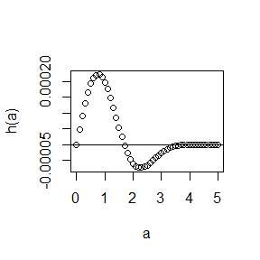

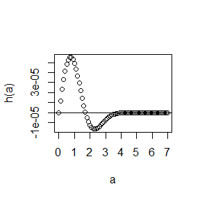

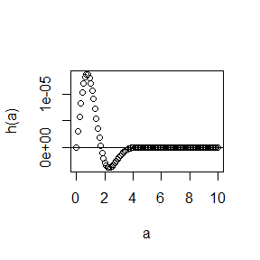

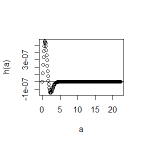

```r
f <- function(a, k) 1-pt(sqrt(a^2*k/(k+1-a^2)), k)
k <- c(25, 50, 100, 500)
for (i in k) {
  h <- function(x) {f(x, i-1)-f(x, i)}
    a <- seq(0, sqrt(i), .1)
  plot(a, h(a), type = 'b')
  abline(h = 0)
}
```

The figures ared plotted when k = 25, 50, 100 and 500. We can conclude that the roots may fall in the interval (1, 2).

```r
f <- function(a, k) 1-pt(sqrt(a^2*k/(k+1-a^2)), k)
k <- c(25:50, 100, 250, 500)
Ak <- numeric(length(k))
i <- 1
for (j in k) {
  g <- function(x) f(x, j-1)-f(x, j)
  Ak[i] <- uniroot(g, lower = 1, upper = 2)$root
  i <- i+1
}
knitr::kable(cbind(k,Ak))
```

| k | Ak |
| --- | --- |
| 25 | 1.687373 |
| 26 | 1.689040 |
| 27 | 1.690587 |
| 28 | 1.692027 |
| 29 | 1.693370 |
| 30 | 1.694626 |
| 31 | 1.695803 |
| 32 | 1.696908 |
| 33 | 1.697948 |
| 34 | 1.698929 |
| 35 | 1.699854 |
| 36 | 1.700729 |
| 37 | 1.701534 |
| 38 | 1.702320 |
| 39 | 1.703067 |
| 40 | 1.703777 |
| 41 | 1.704453 |
| 42 | 1.705098 |
| 43 | 1.705713 |
| 44 | 1.706301 |
| 45 | 1.706863 |
| 46 | 1.707401 |
| 47 | 1.707917 |
| 48 | 1.708411 |
| 49 | 1.708886 |
| 50 | 1.709342 |
| 100 | 1.720608 |
| 250 | 1.727457 |
| 500 | 1.729756 |

In exercise 11.5:

```r
f <- function(k) 2/sqrt(pi*k)*exp(lgamma((k+1)/2)-lgamma(k/2))
ck <- function(a, k) sqrt(a^2*k/(k+1-a^2))
g <- function(u, k) (1+u^2/k)^(-(k+1)/2)
k <- c(25:50, 100, 250, 500)
root <- numeric(length(k))
i <- 1
for (j in k) {
  ff <- function(a) f(j)*integrate(function(u) {g(u, j)}, 0, ck(a, j))$value -       f(j-1)*integrate(function(u) {g(u, j-1)}, 0, ck(a, j-1))$value
  root[i] <- uniroot(ff, lower = 1, upper = 2)$root
  i <- i+1
}
knitr::kable(cbind(k, Ak, root))
```

| k | Ak | root |
| --- | --- | --- |
| 25 | 1.687373 | 1.687373 |
| 26 | 1.689040 | 1.689040 |
| 27 | 1.690587 | 1.690587 |
| 28 | 1.692027 | 1.692027 |
| 29 | 1.693370 | 1.693370 |
| 30 | 1.694626 | 1.694626 |
| 31 | 1.695803 | 1.695803 |
| 32 | 1.696908 | 1.696908 |
| 33 | 1.697948 | 1.697948 |
| 34 | 1.698929 | 1.698929 |
| 35 | 1.699854 | 1.699854 |
| 36 | 1.700729 | 1.700729 |
| 37 | 1.701534 | 1.701534 |
| 38 | 1.702320 | 1.702320 |
| 39 | 1.703067 | 1.703067 |
| 40 | 1.703777 | 1.703777 |
| 41 | 1.704453 | 1.704453 |
| 42 | 1.705098 | 1.705098 |
| 43 | 1.705713 | 1.705713 |
| 44 | 1.706301 | 1.706301 |
| 45 | 1.706863 | 1.706863 |
| 46 | 1.707401 | 1.707401 |
| 47 | 1.707917 | 1.707917 |
| 48 | 1.708411 | 1.708411 |
| 49 | 1.708886 | 1.708886 |
| 50 | 1.709342 | 1.709342 |
| 100 | 1.720608 | 1.720608 |
| 250 | 1.727457 | 1.727457 |
| 500 | 1.729756 | 1.729756 |

The outcomes in ‘Ak’ column are the outcomes in Exercise 11.4 and these in ‘root’ column are the outcomes in Exercise 11.5. We can find from the table that the results are the same. This result is obvious as these two questions are in fact the same.

### Question 3

- A-B-O blood type problem
  - Let the three alleles be A, B, and O.

    | Genotype | AA | BB | OO | AO | BO | AB | Sum |
    | --- | --- | --- | --- | --- | --- | --- | --- |
    | Frequency | p^2 | q^2 | r^2 | 2pr | 2qr | 2pq | 1 |
    | Count | nAA | nBB | nOO | nAO | nBO | nAB | n |

  - Observed data: $n_{A\cdot}=n_{AA}+n_{AO}=28$ (A-type), $n_{B\cdot}=n_{BB}+n_{BO}=24$ (B-type), $n_{OO}=41$ (O-type), $n_{AB}=70$ (AB-type).
  - Use EM algorithm to solve MLE of $p$ and $q$ (consider missing data $n_{AA}$ and $n_{BB}$).
  - Record the log-maximum likelihood values in M-steps, are they increasing?

### Answer

```r
nA <- 28; nB <- 24; nOO <- 41; nAB <- 70

theta_0 <- c(.1, .1)
for (j in 1:1000) {
  E <- function(theta) {
    p <- theta[1]
    q <- theta[2]
    r <- 1-p-q
    p0 <- theta_0[1]
    q0 <- theta_0[2]
    r0 <- 1-p0-q0
    return(2*nA*(log(p)+r0/(p0+2*r0)*log(2*r/p))+2*nB*(log(q)+r0/(q0+2*r0)*log(2*r/q))+2*nOO*log(r)+nAB*log(2*p*q))
  }
  Obj <- function(theta) -E(theta)
  optim <- optim(c(.1, .1), Obj)
  theta_0 <- optim$par
}
print(theta_0)
```

```
## [1] 0.3273325 0.3104528
```

From the result, we obtain the MLE of p and q are 0.3273325 and 0.3104528 respectively according to EM algorithm.

# Homework 11

### Question 3

Use both for loops and lapply() to fit linear models to the mtcars using the formulas stored in this list:

formulas <- list( mpg ~ disp, mpg ~ I(1 / disp), mpg ~ disp + wt, mpg ~ I(1 / disp) + wt )

### Answer

```r
data <- as.matrix(mtcars)
mpg <- data[,1]
disp <- data[,3]
wt <- data[,6]

# for loops
re <- list()
re1 <- mpg ~ disp
re2 <- mpg ~ I(1 / disp)
re3 <- mpg ~ disp + wt
re4 <- mpg ~ I(1 / disp) + wt
h <- c("re1","re2","re3","re4")

for (i in h){
  re[i] <- lm(i)
}
re
```

```
## $re1
## (Intercept)        disp
## 29.59985476 -0.04121512
##
## $re2
## (Intercept)   I(1/disp)
##    10.75202  1557.67393
##
## $re3
## (Intercept)        disp          wt
## 34.96055404 -0.01772474 -3.35082533
##
## $re4
## (Intercept)   I(1/disp)          wt
##   19.024206 1142.559975   -1.797649
```

```r
# lapply
f <- list(mpg ~ disp,
       mpg ~ I(1 / disp),
       mpg ~ disp + wt,
       mpg ~ I(1 / disp) + wt)
lapply(f, lm)
```

```
## [[1]]
##
## Call:
## FUN(formula = X[[i]])
##
## Coefficients:
## (Intercept)         disp
##    29.59985     -0.04122
##
##
## [[2]]
##
## Call:
## FUN(formula = X[[i]])
##
## Coefficients:
## (Intercept)    I(1/disp)
##       10.75      1557.67
##
##
## [[3]]
##
## Call:
## FUN(formula = X[[i]])
##
## Coefficients:
## (Intercept)         disp           wt
##    34.96055     -0.01772     -3.35083
##
##
## [[4]]
##
## Call:
## FUN(formula = X[[i]])
##
## Coefficients:
## (Intercept)    I(1/disp)           wt
##      19.024     1142.560       -1.798
```

### Question 4

Fit the model mpg ~ disp to each of the bootstrap replicates of mtcars in the list below by using a for loop and lapply(). Can you do it without an anonymous function?

bootstraps <- lapply(1:10, function(i) { rows <- sample(1:nrow(mtcars), rep = TRUE) mtcars[rows, ] })

### Answer

```r
set.seed(123)
bootstraps <- lapply(1:10, function(i) {
      rows <- sample(1:nrow(mtcars), rep = TRUE)
      mtcars[rows, ]
      })
# for loops
g <- list()
for (i in 1:10){
  g[i] <- lm(mpg~disp, data = bootstraps[[i]])
}
g
```

```
## [[1]]
## (Intercept)        disp
## 29.59804025 -0.03797831
##
## [[2]]
## (Intercept)        disp
## 27.38760407 -0.03411317
##
## [[3]]
## (Intercept)        disp
## 30.27666550 -0.04175611
##
## [[4]]
## (Intercept)        disp
## 27.25456701 -0.03270754
##
## [[5]]
## (Intercept)        disp
## 29.07161410 -0.04128939
##
## [[6]]
## (Intercept)        disp
## 28.51715577 -0.03935732
##
## [[7]]
## (Intercept)        disp
##  31.7497532  -0.0464673
##
## [[8]]
## (Intercept)        disp
## 27.47887336 -0.03404925
##
## [[9]]
## (Intercept)        disp
##  29.5774947  -0.0404346
##
## [[10]]
## (Intercept)        disp
## 29.60505274 -0.04017415
```

```r
# lapply
#lapply(1:10, FUN = function(x) lm(mpg~disp, data = bootstraps[[x]]) )
lapply(bootstraps, lm, formula = mpg~disp)
```

```
## [[1]]
##
## Call:
## FUN(formula = ..1, data = X[[i]])
##
## Coefficients:
## (Intercept)         disp
##    29.59804     -0.03798
##
##
## [[2]]
##
## Call:
## FUN(formula = ..1, data = X[[i]])
##
## Coefficients:
## (Intercept)         disp
##    27.38760     -0.03411
##
##
## [[3]]
##
## Call:
## FUN(formula = ..1, data = X[[i]])
##
## Coefficients:
## (Intercept)         disp
##    30.27667     -0.04176
##
##
## [[4]]
##
## Call:
## FUN(formula = ..1, data = X[[i]])
##
## Coefficients:
## (Intercept)         disp
##    27.25457     -0.03271
##
##
```

[output cut: 43 more lines]

```
## FUN(formula = ..1, data = X[[i]])
##
## Coefficients:
## (Intercept)         disp
##    29.57749     -0.04043
##
##
## [[10]]
##
## Call:
## FUN(formula = ..1, data = X[[i]])
##
## Coefficients:
## (Intercept)         disp
##    29.60505     -0.04017
```

### Question 5

For each model in the previous two exercises, extract $R^2$ using the function below.

rsq <- function(mod) summary(mod)$r.squared

### Answer

```r
rsq <- function(mod) summary(mod)$r.squared

# exercise 3
m <- lapply(f, lm)
lapply(m, rsq)
```

```
## [[1]]
## [1] 0.7183433
##
## [[2]]
## [1] 0.8596865
##
## [[3]]
## [1] 0.7809306
##
## [[4]]
## [1] 0.8838038
```

```r
# exercise 4
n <- lapply(bootstraps, lm, formula = mpg~disp)
lapply(n, rsq)
```

```
## [[1]]
## [1] 0.6497636
##
## [[2]]
## [1] 0.6820834
##
## [[3]]
## [1] 0.7530595
##
## [[4]]
## [1] 0.6101709
##
## [[5]]
## [1] 0.7226119
##
## [[6]]
## [1] 0.7533418
##
## [[7]]
## [1] 0.7311415
##
## [[8]]
## [1] 0.6293502
##
## [[9]]
## [1] 0.6554375
##
## [[10]]
## [1] 0.7238971
```

### Question 3

The following code simulates the performance of a t-test for non-normal data. Use sapply() and an anonymous function to extract the $p$-value from every trial.

trials <- replicate( 100, t.test(rpois(10, 10), rpois(7, 10)), simplify = FALSE )

Extra challenge: get rid of the anonymous function by using [[ directly.

### Answer

```r
set.seed(1234)
trials <- replicate(
        100,
        t.test(rpois(10, 10), rpois(7, 10)),
        simplify = FALSE
       )

# sapply
l <- function(x) x$p.value
sapply(trials, l)
```

```
##   [1] 0.92573839 0.38341791 0.21070462 0.41458918 0.26121206 0.72223937
##   [7] 0.29887169 0.95162894 0.26398664 0.62018151 0.51388383 0.94676108
##  [13] 0.05206634 0.94395869 0.90872276 0.91948631 0.66419598 0.29837025
##  [19] 0.29940554 0.83506207 0.45274078 0.90320828 0.79263778 0.45399170
##  [25] 0.38923722 0.69542630 0.26739653 0.38567329 0.31137487 0.36010634
##  [31] 0.39754771 0.72253407 0.42186171 0.12771643 0.23170443 0.68265125
##  [37] 0.71252902 0.12724649 0.75353630 0.94884686 0.87276882 0.41388298
##  [43] 0.25224053 0.84404036 0.16580146 0.42473329 0.82280924 0.71272703
##  [49] 0.30947058 0.92816784 0.27134690 0.62008647 0.49758173 0.02775463
##  [55] 0.78775614 0.26248714 0.77273771 0.68416168 0.08687832 0.04574362
##  [61] 0.44178950 0.36827740 0.64265435 0.47847663 0.10832740 0.75695184
##  [67] 0.61642417 0.01474650 0.18023871 0.42316145 0.38702375 0.27030894
##  [73] 0.92266032 0.75504614 0.65781938 0.34910615 0.22083614 0.53165720
##  [79] 0.14727409 0.50490437 0.42920650 0.71256710 0.72931439 0.90676814
##  [85] 0.85988192 0.87366680 0.91047506 0.99255659 0.15198012 0.09537499
##  [91] 0.37213020 0.96151424 0.97595090 0.30669922 0.42738809 0.75571001
##  [97] 0.15155800 0.06214524 0.29324608 0.83599679
```

```r
# Extra challenge
sapply(trials, '[[',3)
```

```
##   [1] 0.92573839 0.38341791 0.21070462 0.41458918 0.26121206 0.72223937
##   [7] 0.29887169 0.95162894 0.26398664 0.62018151 0.51388383 0.94676108
##  [13] 0.05206634 0.94395869 0.90872276 0.91948631 0.66419598 0.29837025
##  [19] 0.29940554 0.83506207 0.45274078 0.90320828 0.79263778 0.45399170
##  [25] 0.38923722 0.69542630 0.26739653 0.38567329 0.31137487 0.36010634
##  [31] 0.39754771 0.72253407 0.42186171 0.12771643 0.23170443 0.68265125
##  [37] 0.71252902 0.12724649 0.75353630 0.94884686 0.87276882 0.41388298
##  [43] 0.25224053 0.84404036 0.16580146 0.42473329 0.82280924 0.71272703
##  [49] 0.30947058 0.92816784 0.27134690 0.62008647 0.49758173 0.02775463
##  [55] 0.78775614 0.26248714 0.77273771 0.68416168 0.08687832 0.04574362
##  [61] 0.44178950 0.36827740 0.64265435 0.47847663 0.10832740 0.75695184
##  [67] 0.61642417 0.01474650 0.18023871 0.42316145 0.38702375 0.27030894
##  [73] 0.92266032 0.75504614 0.65781938 0.34910615 0.22083614 0.53165720
##  [79] 0.14727409 0.50490437 0.42920650 0.71256710 0.72931439 0.90676814
##  [85] 0.85988192 0.87366680 0.91047506 0.99255659 0.15198012 0.09537499
##  [91] 0.37213020 0.96151424 0.97595090 0.30669922 0.42738809 0.75571001
##  [97] 0.15155800 0.06214524 0.29324608 0.83599679
```

### Question 7

Implement $mcsapply()$, a multicore version of $sapply()$. Can you implement $mcvapply()$, a parallel version of $vapply()$? Why or why not?

### Answer

```r
# mcsapply()
library(parallel)
boot_df <- function(x) x[sample(nrow(x), rep = T), ]
rsquared <- function(mod) summary(mod)$r.squared
boot_lm <- function(i) {
  rsquared(lm(mpg ~ wt + disp, data = boot_df(mtcars)))
}
system.time(sapply(1:1e5, boot_lm))
system.time(unlist(mclapply(1:1e5, boot_lm, mc.cores = 4)))
```

In Windows, $mclapply()$ fails. We can not find the results. ‘mc.cores’ > 1 is not supported on Windows

# Homework 12

### Question

You have already written an R function for Exercise 9.4 (page277, Statistical Computing with R). Rewrite an Rcpp function for the same task.

Compare the generated random numbers by the two functions using qqplot.

Campare the computation time of the two functions with microbenchmark.

Comments your results.

### Answer

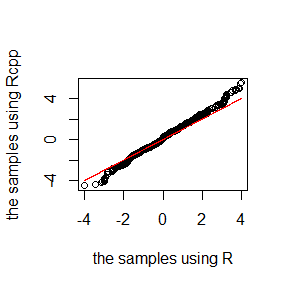

```r
#the function written before
library(kableExtra)
library(GeneralizedHyperbolic)
rw.Metropolis <- function(sigma,x0,N) {
x <- numeric(N)
x[1] <- x0
u <- runif(N)
k <- 0
for (i in 2:N) {
y <- rnorm(1, x[i-1], sigma)
if (u[i] <= exp(abs(x[i-1]) - abs(y))){
x[i] <- y
k <- k + 1}
else {
x[i] <- x[i-1]

} }
return(list(x=x, k=k))
}

#the function using Rcpp
library(Rcpp)
cppFunction('List rw_Metropolis(double sigma, double x0, int N) {
NumericVector x(N);
x[0] = x0;
int k = 0;
for (int i = 1;i < N;i++) {
double u = runif(1)[0];
double y = rnorm(1, x[i-1], sigma)[0];
if (u <= exp(abs(x[i-1]) - abs(y))){
x[i] = y;
k = k + 1;}
else
x[i] = x[i-1];
}
List result = List::create(x,k);
return(result);
}')

#generate random samples
set.seed(123)
N <- 1000
sigma <- 1
x0 <- 0
sample1 <- rw.Metropolis(sigma,x0,N)$x
sample2 <- rw_Metropolis(sigma,x0,N)[[1]]

#qq plot
library(car)
qqplot(sample1, sample2, xlab = "the samples using R",
       ylab = "the samples using Rcpp")
x <- seq(-4,4,.01)
lines(x,x,col = "red")
```

```r
#Campare the computation time
library(microbenchmark)
ts <- microbenchmark(rw1 = rw.Metropolis(sigma,x0,N),rw2 = rw_Metropolis(sigma,x0,N))
summary(ts)[,c(1,3,5,6)]
```

```
##   expr      lq  median     uq
## 1  rw1 3039.00 3274.60 4279.1
## 2  rw2  227.65  235.55  272.4
```

##### **Conclusion :**We can see that the qq plot is close to y = x,which means the samples generated by two samplers are quite similar.By computing the computation time,the time of sampler using R is much more than that of sampler using Rcpp,so Rcpp gives higher performance computation.